# Seminar - Tema6

Vanja Ljubobratović, Karlo Graf, Mauro Gizdulić

2023-01-16

# Seminar - Prikaz slike reljefa u obliku digitalne karte

# Uvod

# Podjela zadatka u nekoliko koraka

1. Preuzeti prostorne podatke za područje otoka Krka
2. Spajanje prostornih podataka
3. Od spojenih podataka odrezati višak
4. Preuzimanje granica otoka Krka
5. Smanjenje rezolucije podataka
6. Definirati Voronoievu teselaciju prostora
7. Provjera modela i statistički testovi

# 1) Preuzeti prostorne podatke za područje otoka Krka

U početku rada seminara naišli smo na nekoliko problema. Jedan od problema bio je preuzeti podatke sa internetske baze CGIAR CSI DEM. Naime internetska baza je ograničila pristup podacima te smo zbog toga tražili alternativnu bazu od kuda bi mogli preuzeti podatke. Kao alternativan način odabrali smo aplikaciju za preuzimanje prostornih podataka s poveznice: https://data.apps.fao.org/catalog/dataset/elevation-cgiar-srtm-dem-v4-near-global-90m/resource/0b2b7b60-4665-467d-a289-7f0503573005, no navedena internetska aplikacija nije mogla preuzeti veliku količinu podataka. Rješenje svih ovih problema pronašli smo u internetskoj bazi: http://dwtkns.com/srtm30m/. Preko navedene poveznice preuzeli smo podatke vezane za otok Krk te potom započeli s kodiranjem. U samome početku istraživali smo koje sve pakete treba koristiti te na temelju istraženog u našem seminaru koristili smo sljedeće pakete:

```r
library(raster)
library(rgdal)
library(ggvoronoi)
library(tidyverse)
library(sp)
library(sf)
library(remotes)
library(rgeoboundaries)
library(data.table)
library(rgeos)
```

- library(raster) -> služi za analizu i modeliranje geografskih podataka, no u našem slučaju paket je bio bitan zbog korištenja funkcije *raster*. Navedena funkcija detaljnije je objašnjena sljedećem koraku.
- library(rgdal) -> služi za vezanje geoprostornih podataka.
- library(ggvoronoi) -> potreban zbog izrade i rukovanje Voronoijevim dijagramima koristeći podpaket *deldir* s vizualizacijom u *ggplot2*. Paket *deldir* ovdje je od velikog značaja jer izračunava Voronoijevu teselaciju (s obzirom na cijelu ravninu) skupa ravninskih točaka.
- library(tidyverse) -> kolekcija r paketa dizajniranih za svakodnevnu upotrebu u radu s podacima(data science).
- library(sp) -> skup klasa i metoda za rad s prostornim podacima. Isto tako sadrži određene funkcije za crtanje podataka u obliku karte i sl.
- library(sf) -> podrška za jednostavne značajke, standardizirani način za enkodiranje vektora prostornih podataka.
- library(remotes) -> služi za instalaciju paketa s udaljenih lokacija kao npr. GitHub ili GitLab.
- library(rgeoboundaries) -> R paket pomoću kojega se mogu dobaviti razne vrlo detaljne granice administrativnih područja pojedinih država.
- library(data.table) -> ekstenzija data.frame, služi za agregaciju velike količine podataka i nudi brze i jednostavno izvedive operacije nad njima.
- library(rgeos) -> sučelje za rad s geometrijskim podacima, korištena zbog funkcije over().

# 2) Spajanje prostornih podataka

Otok Krk nalazio se je na granici dvaju prostornih podataka koje je bilo potrebno povezati u jednu veliku grupu prostornih podataka. U nastavku je prikazan kod:

```r
elevationUp <- raster(paste0("N45E014.hgt"))
elevationDown <- raster(paste0("N44E014.hgt"))
elevationMerge <- mosaic(elevationUp, elevationDown, fun = mean)
```

Varijable *elevationUp* i *elevationDown* koriste funkciju *raster* koja od preuzetih podataka kreira Raster sloj i sprema ih kao raster objekt. Varijabla *elevationMerge* uz pomoć funkcije *mosaic* povezuje dva rasterska objekta u jedan veliki. Ključni parametar ove funkcije je *fun = mean* .

# 3) Od spojenih podataka odrezati višak

U prethodnome koraku vidjeli smo da su prostorni podaci povezani u varijablu *elevationMerge*. Kako navedena varijabla sadrži sve podatke, odnosno podatke geografske širine od 44° do 46° te geografske dužine od 14° do 15°, potrebno je bilo prema zadatku prikazati samo otok Krk. Prvi način koji smo koristili bio je:

```r
pt <- cbind(14.61, 45.1)
points(pt)
size <- 0.21
```

Prikazani kod je spremio centralnu točku otoka Krka u varijablu *pt*. Zatim se je navedena varijabla proširila za određeni *size* u svim smjerovima i time prikazala kao otok Krk uz pomoć funkcije *plot*. Ovaj način prikazivanja otoka nije bio dobar jer iako je otok ispravno prikazan i dalje su se uzimali svi podaci, stoga kao rješenje ovog problema koristili smo funkciju *crop*. Uz pomoć naveden funkcije uzeli smo (ili odrezali) samo podatke od otoka Krka koje iznose u geografskoj širini od 44.936° do 45.257° i u geografskoj dužini od 14.43° do 14.82°.

```r
map <- crop(elevationMerge, extent(14.43, 14.82, 44.936, 45.257))
```

# 4) Preuzimanje administrativnih granica Krka

```r
sf_use_s2(FALSE)
```

```
## Spherical geometry (s2) switched off
```

```r
#preuzimanje granica i ekstrakcija granica Krka
croatia = geoboundaries("Croatia", "adm1")
pgz = subset(croatia, shapeName=="Primorje-Gorski Kotar")
borders = c(xmin = 14.43, ymin = 44.936, xmax = 14.82, ymax = 45.257)
krk = st_crop(pgz, borders)
```

```
## although coordinates are longitude/latitude, st_intersection assumes that they
## are planar
```

```r
#pretvorba dobivenih podataka u data.table objekt
st_geometry(krk)
```

```
## Geometry set for 1 feature
## Geometry type: MULTIPOLYGON
## Dimension:     XY
## Bounding box:  xmin: 14.43 ymin: 44.936 xmax: 14.82 ymax: 45.257
## Geodetic CRS:  WGS 84
```

```
## MULTIPOLYGON (((14.54095 44.95297, 14.54072 44....
```

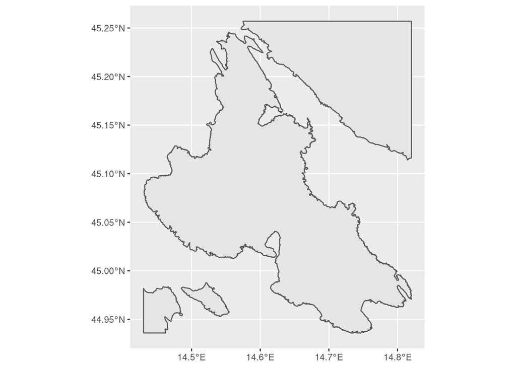

```r
krk_geom = krk$geometry
krk_dt = data.table(do.call(cbind, krk_geom[[1]][[2]]))

#imenovanje stupaca
colnames(krk_dt) = c ("lon", "lat")

#izbacivanje dvostrukih vrijednosti
klong = unique(krk_dt$long)
klat = unique(krk_dt$lat)

#dodavanje stupca “group”
krk_dt[ , `:=` (group = 4)]

#plot za provjeru
ggplot(krk_geom) + geom_sf()
```

Postupak izvlačenja granica otoka Krka je sljedeći: Preuzeti administrativne granice Republike Hrvatske Izvući podset podataka koji se odnosi na Primorsko-goransku županiju Pomoću koordinata ručno izmjerenih na karti, odsjeći što više nebitnih podataka oko otoka Krka Iz dobivenog objekta izvući podatke isključivo o geografskoj dužini i širini te ih pretvoriti u tablični objekt uz pravilno imenovane stupce (“lon”, “lat”, “group” -> ggvoronoi zahtjeva stupac group, ali pored toga on nema nikakvo značenje) U dobivenoj tablici ostaviti samo jedinstvene podatke

Sada postoji varijabla krk_dt u obliku podatkovne tablice koja će se koristiti kao outline prilikom Voronoieve teselacije funkciji. Pri završteku opisanog postupka za provjeru je rezultat i nacrtan pomoću ggplot knjižnice.

# 5) Pretvorba podataka iz 30m rezolucije u 360m rezoluciju

Jedan od glavnih zadataka ovoga seminara bio je kreirati digtalnu kartu Krka koristeću se SRTM podacima rezolucije 360m. Nažalost, ti podaci nisu bili dostupni pa su preuzeti SRTM podaci rezolucije 30m. Kako bi se približili originalnom zahtjevu seminara, i zbog činjenice da je bilo računalno prezahtjevno izračunati Voronoievu teselaciju prostora s tolikom količinom podataka, na dostupnim računalima, dobivene podatke je odlučeno pretvoriti u rezoluciju od 360m. Sužavanje podataka je odrađeno tako da je iz svakog 12x12(360m) područja uzeta samo središnja točka. Kao alternativa pokušan je uzet prosjek svih 12x12 točaka, no to je rezultiralo lošijom finalnom kartom pa je odbačena. Prvi korak u smanjenju rezolucije podataka bio je pretvaranje raster podataka u podatkovni okvir te dodjela imena stupcima. Također napravljena je kopija podatkovnog okvira za kasniju analizu, budući da trenutni kasnije transformiramo.

```r
srtmPoints <- rasterToPoints(map)
srtmFrame <- data.frame(srtmPoints)

colnames(srtmFrame) = c("lat", "lon", "alt")
srtmFull <- srtmFrame
```

Nakon toga, bilo je potrebno zapisati visinu i širinu središnjih točaka jer bi se koordinate izgubile prilikom izračuna. Koordinate su pročitane iz podakovnog okvira, maknuti su duplikati te je uzeta svaka 12-ta vrijednost, počevši od šeste.

```r
lonvals <- srtmFrame$lon
latvals <- srtmFrame$lat
lonvals <- unique(lonvals)
latvals <- unique(latvals)

lonvals <- lonvals[seq(6, length(lonvals), 12)]
latvals <- latvals[seq(6, length(latvals), 12)]
```

Zbog toga što su podaci zapisani u “jedno dimenzionalnoj” tablici, tkz. “long table” formatu potrebno ih je pretvoriti u široki format kako bi dohvat srednje točke bio lakši. Za to se koristila reshape funkcija, te je prvi red u okviru obrisan jer sadrži geografsku širinu koja bi kasnije smetala kod pretvorbe.

```r
srtmFrame <- reshape(srtmFrame, idvar="lon", timevar = "lat", direction = "wide")
rownames(srtmFrame) <- srtmFrame[,1]
srtmFrame[,1] <- NULL
```

Nakon pretvorbe kreiran je novi podatkovni okvir koji se sastoji samo od središnjih točaka, postavlja se geografska širina i visina te se podatkovni okvir pretvara nazad u long format funkcijom melt, kako bi se mogao koristiti za Voronoievu teselaciju prostora. Na samome kraju bilo je potrebno pretvoriti vrijednost geografske visine u numeric, jer se tijekom pretvorbe podataka postavila u factor.

```r
newSrtm <- srtmFrame

#uzima se središna točka 12x12 područja
newSrtm = newSrtm[seq(6, nrow(newSrtm), 12), ]
newSrtm = newSrtm[, seq(6, ncol(newSrtm), 12)]

#postavlja se geografska širina i visina
colnames(newSrtm) <- latvals
newSrtm$lon <- lonvals

#podatkovni okvir se pretvara nazad u long format kako bi se mogao koristit za Voronoievu tesalaciju
longSrtm <- melt(setDT(newSrtm), id.vars = "lon", variable.name = "lat")

#postavljaju se imena stupaca
colnames(longSrtm) = c("lat", "lon", "value")

#vrijednost geografske visine se pretvara u numeric za korištenje u Voronoi-u
longSrtm$lon = as.numeric(as.character(longSrtm$lon))
```

Ovim postupkom podaci su pretvoreni iz 30m rezolucije u 360m rezoluciju.

# 6) Definirati Voronoievu teselaciju prostora i generacija karte

Voronoi diagram crta regije najbližih susjeda oko skupa točka te je specificiranjem argumenta popune moguće nacrtati toplinsku kartu, što je i napravljeno. Argument popune je u ovome slučaju visina te SRTM točke te su Voronoieve ćelije pravokutnog oblika jer su satelitska mjerenja izvršena s jednakom udaljenošću. Prilikom izrade toplinske mape bilo je potrebno specificirati boje za izražavanje visine. Korištena je standardna paleta boja, uz određene dodatke zbog razlika u visini Krka i Kalifornije koja je prikazana u tutorialu. Također podešene su i granice za visine sukladno reljefu otoka Krka. Prilikom crtanja karte uz pomoć ggplot funkcije granica otoka Krka preuzeta u prvome dijelu rada korištena je kao omeđujući objekt za Voronoievu teselaciju. Funkcija scale_fill_gradient i scale_colour_gradient dodjeljuju gradijente boja ćelijama. Funkcija theme_minimal definira pozadinu plota dok sa funkcijom theme se ne prikazuju x i y osi. Geom_path crta granicu otoka Krka, funkcija je isključivo vizualna, ne služi pri računanju. Geom_voronoi zapravo računa Voronoievu teselaciju na koju se onda primjenjuju iznad spomenute funcije. Rezultat je digitalna karta elevacije otoka Krka, prikazana ispod.

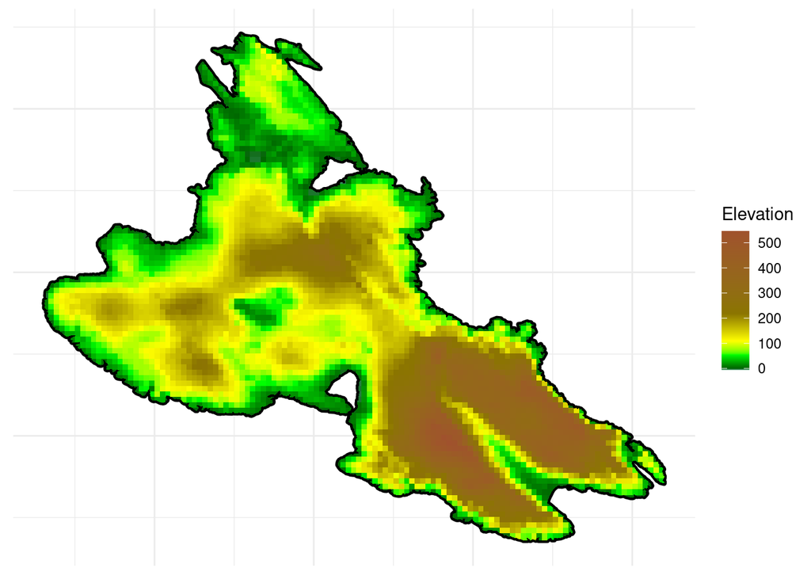

```r
ggplot(longSrtm) +
  scale_fill_gradientn("Elevation",
                       colors=c("seagreen","darkgreen","green1","yellow","gold4", "sienna"),
                       values=scales::rescale(c(-5,0,50,100,200,500))) +
  scale_colour_gradientn("Elevation",
                        colors=c("seagreen","darkgreen","green1","yellow","gold4", "sienna"),
                        values=scales::rescale(c(-5,0,50,100,200,500))) +
  theme_minimal() +
  theme(axis.text=element_blank(),
        axis.title=element_blank()) +
  geom_path(data=krk_dt, aes(lon, lat, group=group), color="black", size=1.5) +
  geom_voronoi(aes(lon, lat, fill = value), outline=krk_dt)
```

# Provjera modela i opisna statistička analiza

```r
#Kreiranje Voronoi teselacije Krka
krk_voronoi <- voronoi_polygon(data=longSrtm, x="lon", y="lat", outline=krk_dt)
```

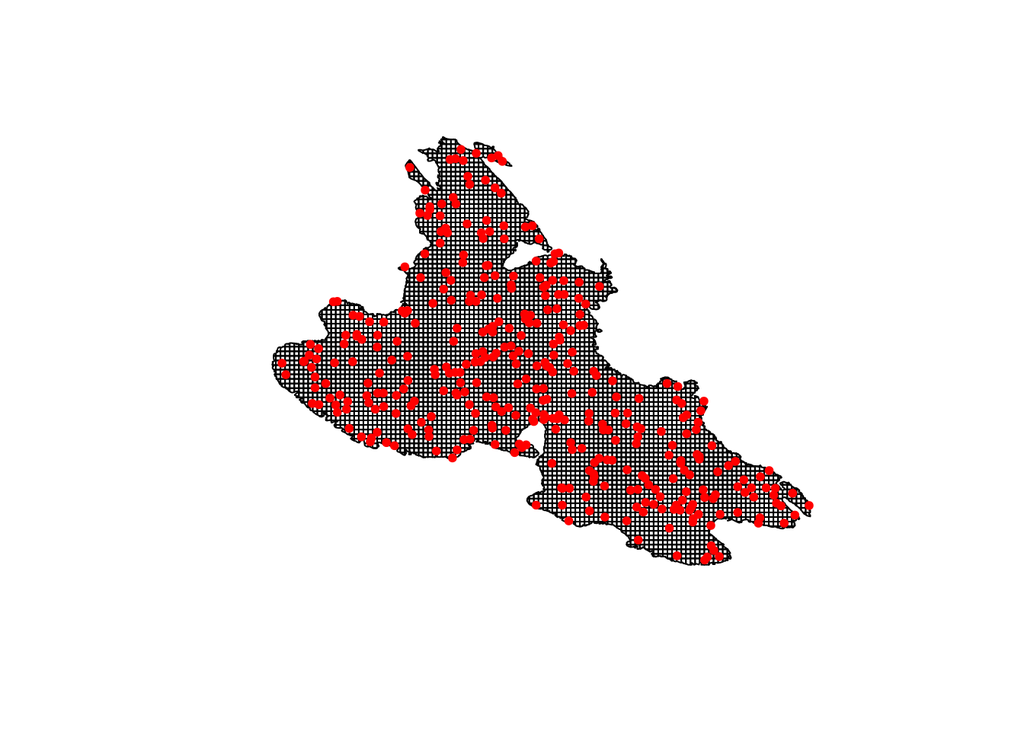

```r
#Nasumično biranje 1000 točaka iz 30m baze, pretovorba tih točaka u SpatialPointsDataFrame
set.seed(123)
n_points <- 1000
random_indeces <- sample(1:nrow(srtmFull), size=n_points, replace=FALSE)
random_points_df <- srtmFull[random_indeces,]
random_points <- SpatialPointsDataFrame(coords=cbind(random_points_df$lat, random_points_df$lon),
                                        data=data.frame(value=random_points_df$alt))

#Dobivanje liste točaka koji se nalaze unutar Voronoi-a(jer je ograđen granicama Krka)
points_over_voronoi <- over(random_points, krk_voronoi)

#Izbacivanje NA vrijednosti tj. točaka koje se nalaze u moru
indeces_not_na <- which(!is.na(points_over_voronoi$group))
points_over_voronoi <- points_over_voronoi[indeces_not_na,]
random_points <- random_points[indeces_not_na,]

#Izračun reziduala tj. razlike između predviđene i stvarne vrijednosti
height_diff <- random_points$value - points_over_voronoi$value
points_in_polygon <- gContains(krk_voronoi, random_points, byid = TRUE)

#Prikaz nasumično izabranih točaka
plot(krk_voronoi)
plot(random_points, col="red", pch=20, add=TRUE)
```

Za početak statističke analize izračunati su kvartili, medijan, prosjek i standardna devijacija. Rezultati su prikazani ispod.

```r
#Statistička analiza
summary(height_diff)
```

```
##     Min.  1st Qu.   Median     Mean  3rd Qu.     Max.
## -80.0000  -7.0000   0.0000  -0.3871   6.0000  63.0000
```

```r
sd(height_diff)
```

```
## [1] 14.27458
```

Također je nacrtan boxplot dijagram, te je iskorišten Shapiro-Wilk test i Kolmogorov-Smirnov test kako bi se provjerila sličnost raziobe reziduala s Gaussovom razdiobom. U odnosu na Shapiro-Wilk test Kolmogorov-Smirnov test je mnogo precizniji.

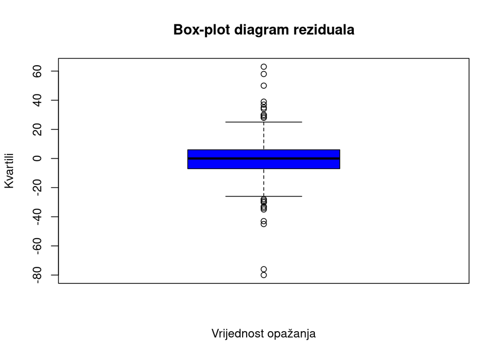

```r
#Boxplot dijagram
boxplot(height_diff, col = 'blue', main='Box-plot diagram reziduala', xlab='Vrijednost opažanja', ylab='Kvartili')
```

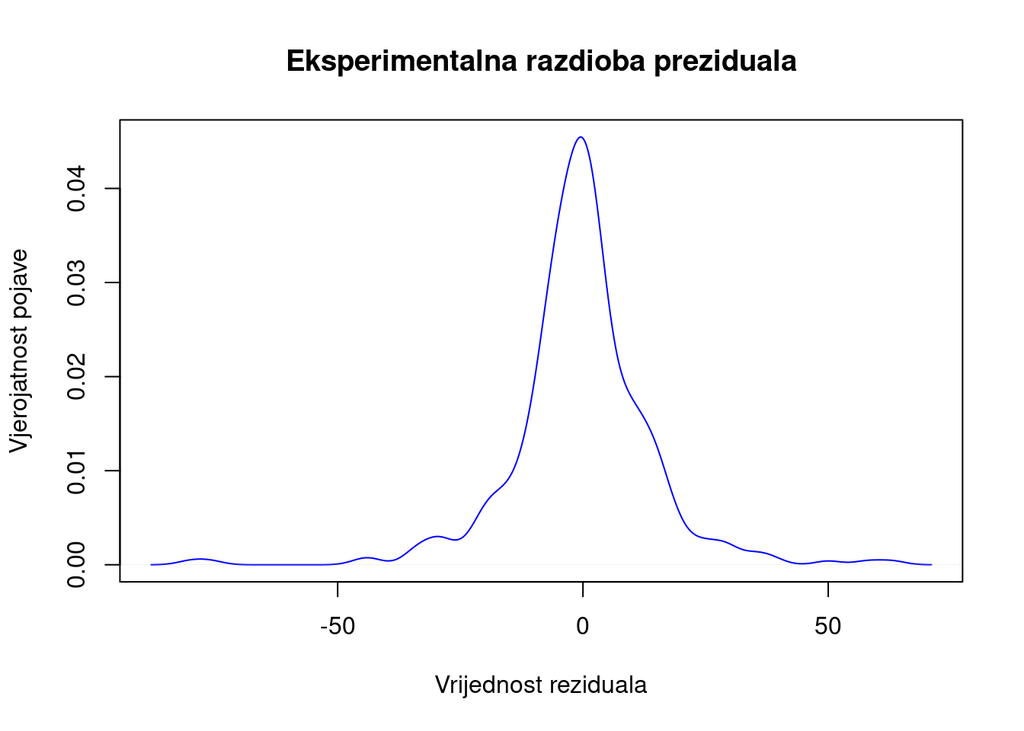

```r
plot(density(height_diff), col='blue', main='Eksperimentalna razdioba preziduala',
     xlab='Vrijednost reziduala', ylab='Vjerojatnost pojave')
```

```r
#Shapiro test
print(shapiro.test(height_diff))
```

```
##
##  Shapiro-Wilk normality test
##
## data:  height_diff
## W = 0.90932, p-value = 3.834e-14
```

```r
print(ks.test(height_diff, 'pnorm'))
```

```
##
##  Asymptotic one-sample Kolmogorov-Smirnov test
##
## data:  height_diff
## D = 0.42886, p-value < 2.2e-16
## alternative hypothesis: two-sided
```

U oba testa dobivena je p vrijednost <0.05 što znači da odbacujemo nultu hipotezu tj. zaključujemo da podaci ne slijede normalnu razdiobu.

# Finalni komentari i zaključak